# PA1_RR

eva16915

March 14, 2016

## Summary

This is a markdown file to report Reproduciable Rearch project assignment 1(to explor people activity status by using movment data from monitoring device).

## Introduction

It is now possible to collect a large amount of data about personal movement using activity monitoring devices such as a Fitbit, Nike Fuelband, or Jawbone Up. These type of devices are part of the “quantified self” movement - a group of enthusiasts who take measurements about themselves regularly to improve their health, to find patterns in their behavior, or because they are tech geeks. But these data remain under-utilized both because the raw data are hard to obtain and there is a lack of statistical methods and software for processing and interpreting the data.

This assignment makes use of data from a personal activity monitoring device. This device collects data at 5 minute intervals through out the day. The data consists of two months of data from an anonymous individual collected during the months of October and November, 2012 and include the number of steps taken in 5 minute intervals each day.

### Loading and preprocessing the data

- Load the data (i.e. read.csv()) and transfer data format from factory to date

```r
setwd("d:/R/data/RR_1")
activity <- read.csv("activity.csv")
dateformat <- "%Y-%m-%d"
activity$date <- as.Date(activity$date, dateformat)
```

### What is mean total number of steps taken per day?

- Calculate the total number of steps taken per day-aggregate() function to sum steps taken by day

```r
steps_per_day <- aggregate(steps ~ date, activity, sum, na.rm = FALSE)
```

- If you do not understand the difference between a histogram and a barplot, research the difference between them. Make a histogram of the total number of steps taken each day

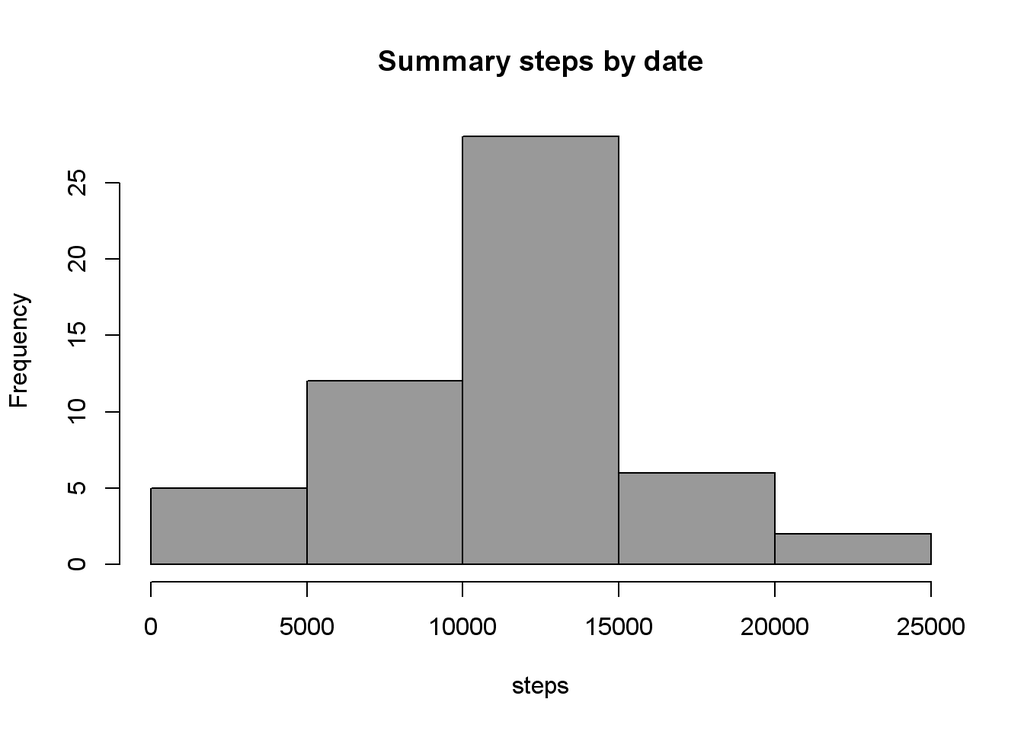

```r
hist(steps_per_day$steps, xlab = "steps", main = "Summary steps by date" , col = "grey60")
```

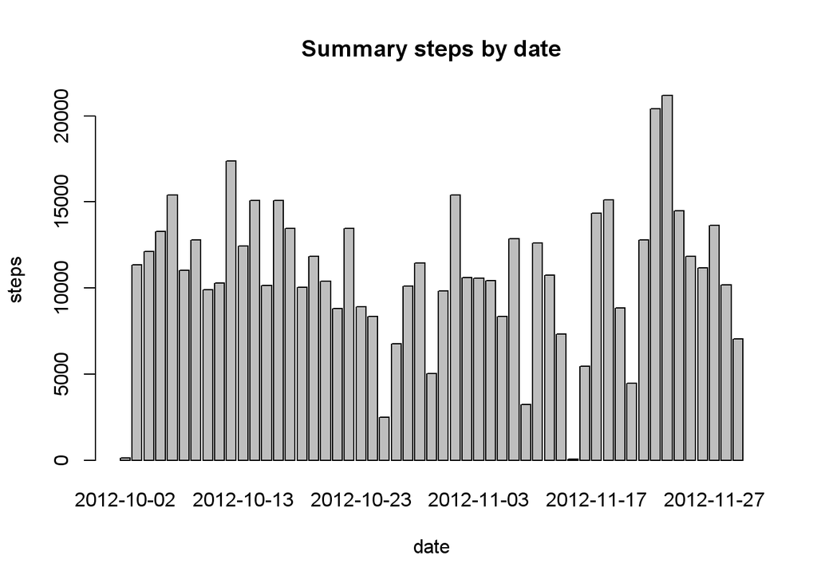

```r
barplot(height=steps_per_day$steps, names.arg=steps_per_day$date, xlab="date", ylab= "steps",main="Summary steps by date")
```

```r
step_mean <- mean(steps_per_day$steps)
step_median <- median(steps_per_day$steps)
```

### What is the average daily activity pattern?

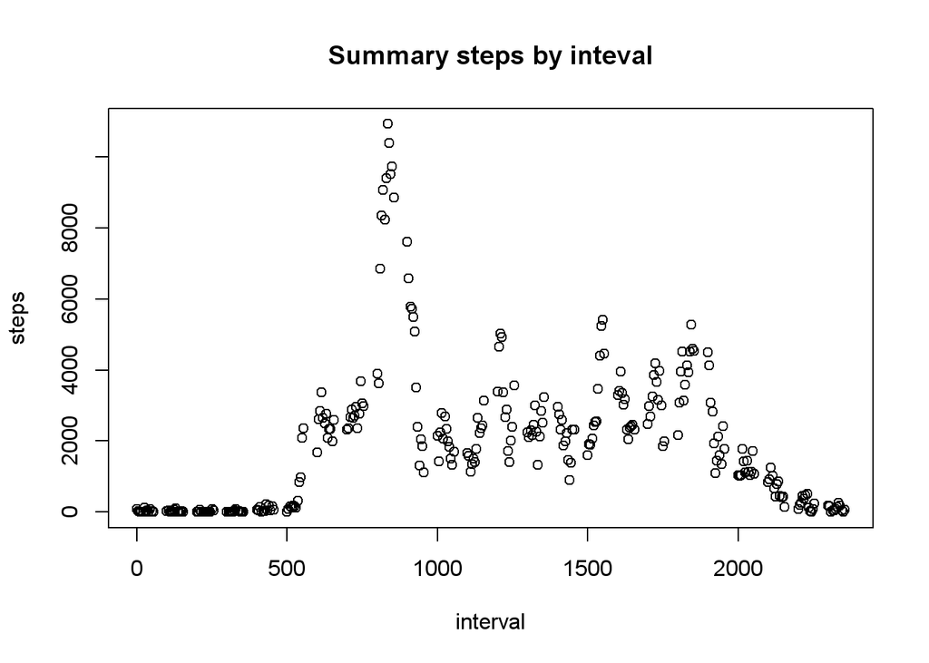

```r
steps_per_interval <- aggregate(steps ~ interval, activity, sum)
plot(steps_per_interval$interval, steps_per_interval$steps, lty = 1, xlab="interval", ylab= "steps",main="Summary steps by inteval")
```

- Which 5-minute interval, on average across all the days in the dataset, contains the maximum number of steps?

```r
max_steps <- max(steps_per_interval$steps)
max_interval <- steps_per_interval[match(max_steps, steps_per_interval$steps),1]
```

> The maximum number is 10927 happens in interval 835

### Imputing missing values

> Note that there are a number of days/intervals where there are missing values (coded as NA). The presence of missing days may introduce bias into some calculations or summaries of the data.
- Calculate and report the total number of missing values in the dataset (i.e. the total number of rows with NAs)

```r
num_missing <- sum(is.na(activity$steps))
```

> Total mission value is 2304
- Devise a strategy for filling in all of the missing values in the dataset. The strategy does not need to be sophisticated. For example, you could use the mean/median for that day, or the mean for that 5-minute interval, etc.Create a new dataset that is equal to the original dataset but with the missing data filled in.

```r
NApos <- which(is.na(activity$steps))
activity[NApos, "steps"] <- mean(activity$steps, na.rm = TRUE)
head(activity)
```

```
##     steps       date interval
## 1 37.3826 2012-10-01        0
## 2 37.3826 2012-10-01        5
## 3 37.3826 2012-10-01       10
## 4 37.3826 2012-10-01       15
## 5 37.3826 2012-10-01       20
## 6 37.3826 2012-10-01       25
```

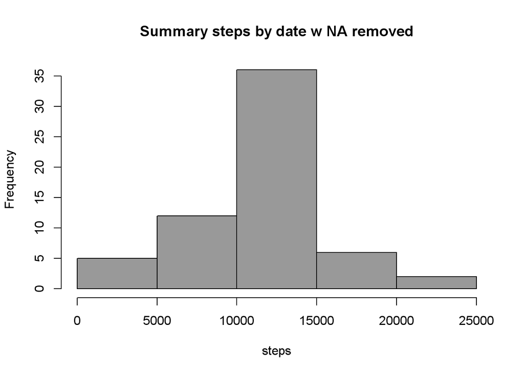

```r
new_steps_per_day <- aggregate(steps ~ date, activity, sum)
hist(new_steps_per_day$steps, xlab = "steps", main = "Summary steps by date w NA removed", col = "grey60")
```

```r
new_step_mean <- mean(new_steps_per_day$steps)
new_step_median <- median(new_steps_per_day$steps)
```